# PML Prediction Model

Ehab Mohamed

27 December 2015

## Executive Summary

The aim of this report is to build a prediction model which is capable of predicting the “classe” variable which represents the manner in which the participants did the exercise. The model starts with loading both training and testing datasets and then cleaning the data to include only the required predictors. The model then uses partitioning to produce new testing set extracted from the original training set. Preprocessing then takes place before performing model training using **Random Forest** technique. The model then examines its predictions accuracy against the extracted new testing set. Finally, the model uses the original testing set to predict the “classe” variable.

## Loading training and testing datasets

The model initially downloads both training and testing files and then loads them into `training` and `testing` datasets respectively.

```r
destTrainingFile <- "pml-training.csv"
destTestingFile <- "pml-testing.csv"

if(!file.exists(destTrainingFile))
    download.file(url = "https://d396qusza40orc.cloudfront.net/predmachlearn/pml-training.csv", destfile = destTrainingFile)
if(!file.exists(destTestingFile))
    download.file(url = "https://d396qusza40orc.cloudfront.net/predmachlearn/pml-testing.csv", destfile = destTestingFile)

training <- as.data.frame(read.csv(destTrainingFile, na.strings = c("NA","","#DIV/0!")))
testing <- as.data.frame(read.csv(destTestingFile, na.strings = c("NA","","#DIV/0!")))
```

## Cleaning data

The model excludes unnecessarily columns and columns with near to zero variance from the datasets.

```r
excludedColumns <- c("X",
                     "user_name",
                     "raw_timestamp_part_1",
                     "raw_timestamp_part_2",
                     "cvtd_timestamp",
                     "new_window",
                     "num_window")
testing <- testing[, !names(testing) %in% excludedColumns]
training <- training[, !names(training) %in% excludedColumns]

nzv <- nearZeroVar(training)
testing <- testing[,-nzv]
training <- training[,-nzv]
```

## Partitioning training set into two datasets

The model then produces new training `myTraining` (90%) and testing `myTesting` (10%) datasets from the original training set in order to examine its prediction accuracy against a new testing set.

```r
inTrain <- createDataPartition(y = training$classe, p = 0.9, list = FALSE)
myTraining <- training[inTrain,]
myTesting <- training[-inTrain,]
dim(myTraining); dim(myTesting)
```

```
## [1] 17662   118
```

```
## [1] 1960  118
```

## Defining training control

The model defines a training control which targets to produce 10 K-folds for cross validation usage.

```r
train_control <- trainControl(method="cv", number=10, index=createFolds(myTraining$classe), allowParallel=TRUE)
```

## Pre-processing training dataset

The model performs preprocessing using the following techniques:

- K nearest neighbor imputation **knnImpute**
- Principal component signal **PCA**

```r
preProc <- preProcess(myTraining[,-118], method = c("knnImpute","pca"))
preProc
```

```
## Created from 191 samples and 117 variables
##
## Pre-processing:
##   - centered (117)
##   - ignored (0)
##   - 5 nearest neighbor imputation (117)
##   - principal component signal extraction (117)
##   - scaled (117)
##
## PCA needed 43 components to capture 95 percent of the variance
```

```r
trainPC <- predict(preProc, myTraining[,-118])
```

The pre-processing shows that only 43 variables are required to capture 95 percent of the variance.

## Training the model

The model the performs training using **Random Forest** technique.

```r
model <- train(myTraining$classe~., data=trainPC, method="rf", trControl=train_control, importance = TRUE)
```

```r
model
```

```
## Random Forest
##
## 17662 samples
##    42 predictor
##     5 classes: 'A', 'B', 'C', 'D', 'E'
##
## No pre-processing
## Resampling: Cross-Validated (10 fold)
## Summary of sample sizes: 1768, 1766, 1766, 1767, 1766, 1765, ...
## Resampling results across tuning parameters:
##
##   mtry  Accuracy   Kappa      Accuracy SD  Kappa SD
##    2    0.8115981  0.7615911  0.009178038  0.01159441
##   22    0.7938513  0.7392849  0.009453014  0.01187640
##   43    0.7841570  0.7270300  0.011706189  0.01471400
##
## Accuracy was used to select the optimal model using  the largest value.
## The final value used for the model was mtry = 2.
```

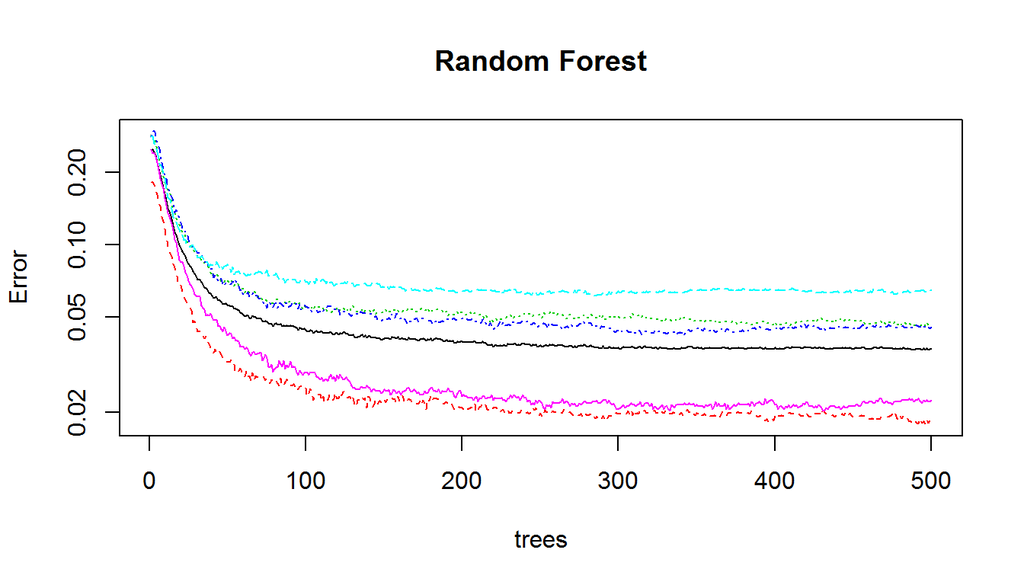

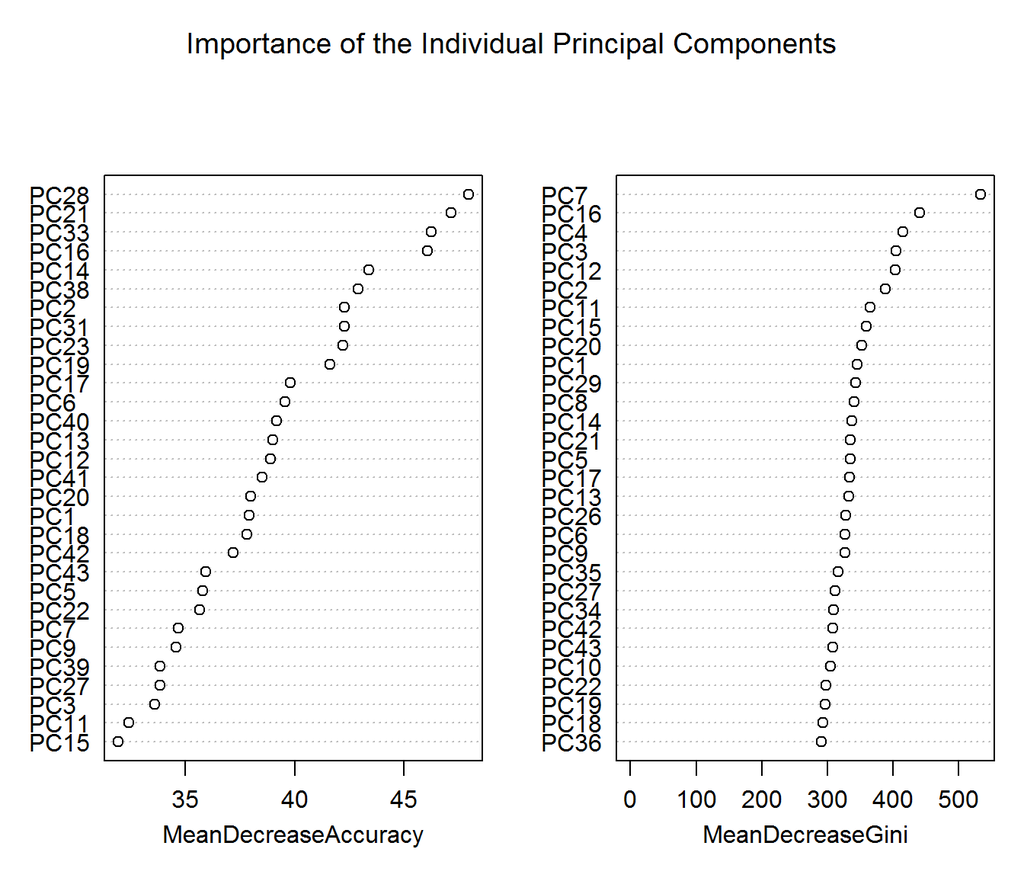

## Pre-processing new extracted testing dataset

The model then processes the new extracted testing dataset `myTesting` using the training pre-processing.

```r
myTestPC <- predict(preProc, myTesting[,-118])
```

## Summarizing results

The below **Confusion Matrix** examines the model against the new extracted testing dataset to measure the out of sample error.

The results show that the accuracy of the model has reached 96%.

```r
confusionMatrix(myTesting$classe, predict(model, myTestPC))
```

```
## Confusion Matrix and Statistics
##
##           Reference
## Prediction   A   B   C   D   E
##          A 547   5   4   1   1
##          B  17 354   6   1   1
##          C   4   6 328   4   0
##          D   1   2  13 302   3
##          E   0   2   5   1 352
##
## Overall Statistics
##
##                Accuracy : 0.9607
##                  95% CI : (0.9511, 0.9689)
##     No Information Rate : 0.2903
##     P-Value [Acc > NIR] : < 2e-16
##
##                   Kappa : 0.9503
##  Mcnemar's Test P-Value : 0.04056
##
## Statistics by Class:
##
##                      Class: A Class: B Class: C Class: D Class: E
## Sensitivity            0.9613   0.9593   0.9213   0.9773   0.9860
## Specificity            0.9921   0.9843   0.9913   0.9885   0.9950
## Pos Pred Value         0.9803   0.9340   0.9591   0.9408   0.9778
## Neg Pred Value         0.9843   0.9905   0.9827   0.9957   0.9969
## Prevalence             0.2903   0.1883   0.1816   0.1577   0.1821
## Detection Rate         0.2791   0.1806   0.1673   0.1541   0.1796
## Detection Prevalence   0.2847   0.1934   0.1745   0.1638   0.1837
## Balanced Accuracy      0.9767   0.9718   0.9563   0.9829   0.9905
```

## Pre-processing testing dataset

The model then processes the original testing dataset `testing` using the training pre-processing.

```r
testPC <- predict(preProc, testing[,-118])
```

## Making testing predictions

Finally, the model predicts the “classe” variable using the original testing dataset.

```r
predictions <- predict(model, testPC)
predictions
```

```
##  [1] B A B A A E D B A A B C B A E E A B B B
## Levels: A B C D E
```